# Mixed effect Model

Neelotpal Das

Assume you knew nothing about male and female, and you were interested in whether the voice pitch of males and females differs, and if so, by how much.What factors do they depend on?We shall use Bodo Winter’s `politeness_data` to verify these hypothesis.

we’re aiming for a relationship that looks like something like this:

`frequency of voice ~ politeness+gender+scenario`

where politeness is treated as a categorical factor with two levels. ~ *polite &informal*

Our design was so that we took multiple measures per subject. That is, each subject gave multiple polite responses and multiple informal responses under different circumstances.(for eg. asking for a cup of coffee,making excuses for coming in late etc. ) Every person has a slightly different voice pitch, and this is going to be an idiosyncratic factor that affects all responses from the same subject, thus rendering these different responses inter-dependent rather than independent.

## Now we shall begin the modelling

Load the necessaary packages and the data

```r
library(lme4)
politeness <- read.csv("politeness_data.csv")
(head(politeness))
```

```
##   subject gender scenario attitude frequency
## 1      F1      F        1      pol     213.3
## 2      F1      F        1      inf     204.5
## 3      F1      F        2      pol     285.1
## 4      F1      F        2      inf     259.7
## 5      F1      F        3      pol     203.9
## 6      F1      F        3      inf     286.9
```

```r
which(is.na(politeness$frequency)) # missing data check
```

```
## [1] 39
```

Minor missing value doesnot impact our analysis , which are usually based on mean (groupwise).

# Exploratory Data Analysis

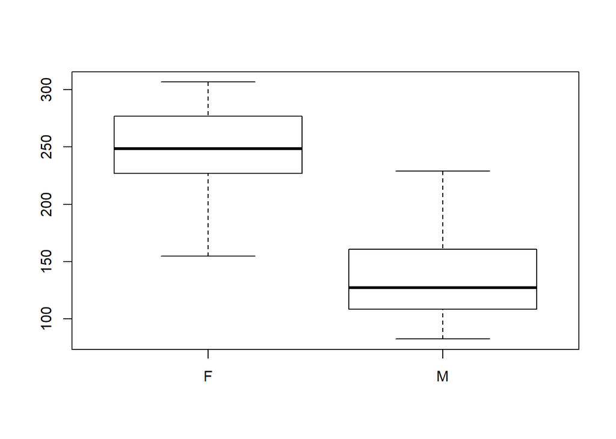

```r
boxplot(frequency~gender,data=politeness)
```

### Let’s begin by looking at the relationship between politeness and pitch by means of a boxplot

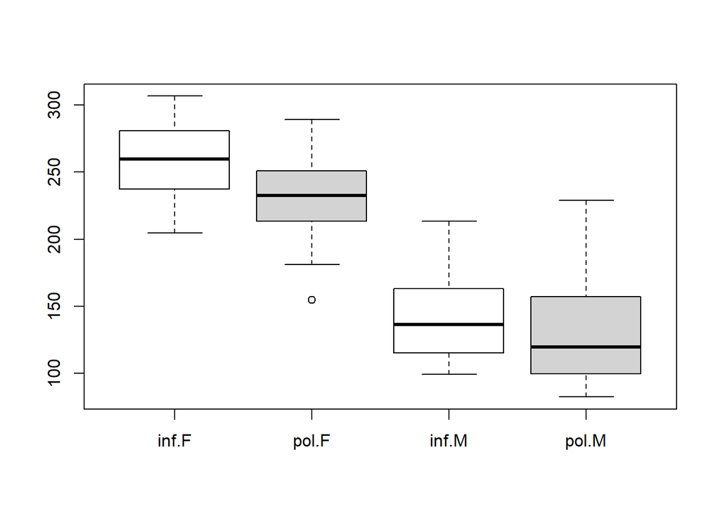

```r
boxplot(frequency ~ attitude*gender,
        col=c("white","lightgray"),politeness)
```

We can clearly notice the differences in pitch among genders under different attitudes.

### Now for the relationship between scenario vs pitch

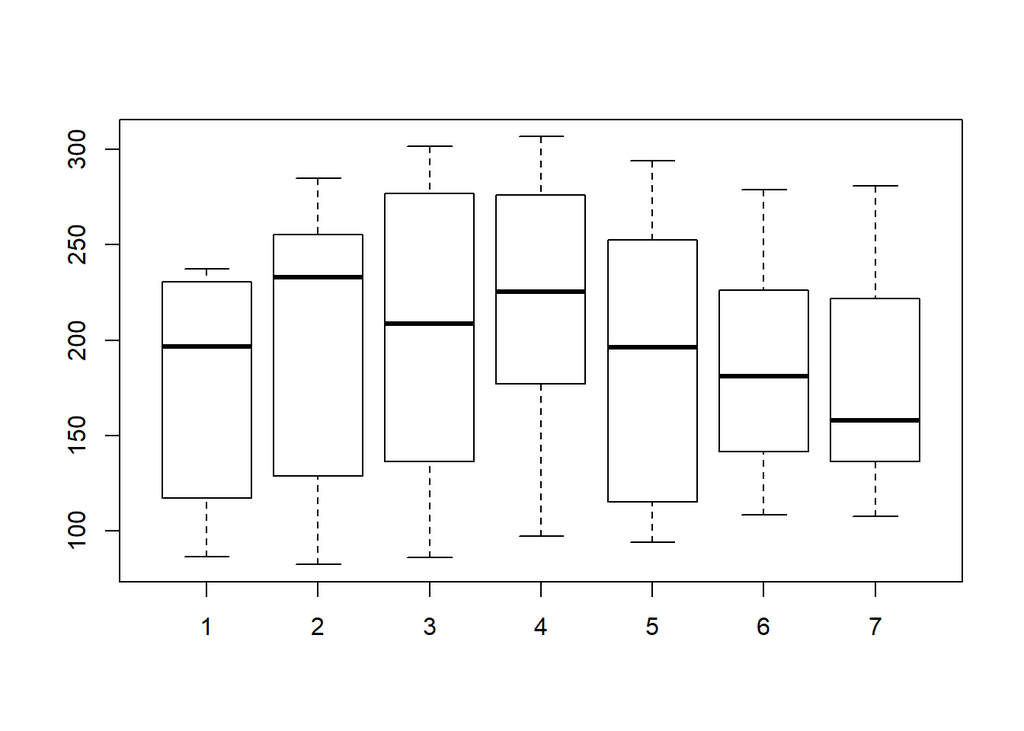

```r
boxplot(frequency~scenario,politeness)
```

This plot makes me think:**Does the pitch vary significantly between scenarios?**.We shall use ANOVA to answer this question.

```r
politeness$scenario <- as.factor(politeness$scenario) #turning them into factors
scen.aov <- aov(frequency~scenario,data=politeness)
summary(scen.aov)
```

```
##             Df Sum Sq Mean Sq F value Pr(>F)
## scenario     6  17924    2987   0.679  0.667
## Residuals   76 334313    4399
## 1 observation deleted due to missingness
```

Overall we can say that there is not much difference among frequency values , with respect to scenarios.In Statistical terms variance in frequency values cannot be attributed to change in scenarios , because`p-value = 0.667` , which is higher than 0.05 .

### Relationship between subjects and frequency

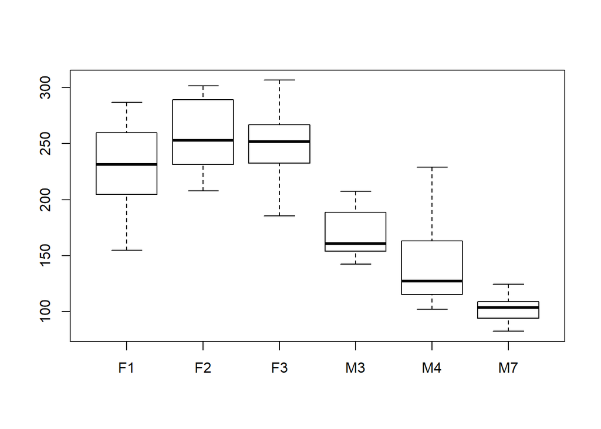

```r
boxplot(frequency~subject,politeness)
```

The variation in frequencies between subjects is clearly visible from this plot.

## Why Mixed Effects Model?

Good Question, Because there are both *fixed* and *random effects* present.

*what are these fixed and random effects and how do you classify them?* A thumb rule for knowing fixed effects are that they exhaust “the levels of a factor” .For example *gender* is always a fixed effect because there can be only 2 types:-(male& female) *Scenarios* can be infinite in number , but for this experiment we took a random sample of only 7 scenarios.In this kind of situation where covariates respresent a sample of the population , we call these covariates “random effects”.

Suppose , frequency depends inherently on the scenario and the subject.Thus we begin our $1^{st}$ model, where we **assume** scenario and subject to a random effect.

## Construction of Linear Mixed Model

```r
politeness.model <- lmer(frequency~attitude+(1|subject)+(1|scenario),data=politeness)
summary(politeness.model)
```

```
## Linear mixed model fit by REML ['lmerMod']
## Formula: frequency ~ attitude + (1 | subject) + (1 | scenario)
##    Data: politeness
##
## REML criterion at convergence: 793.5
##
## Scaled residuals:
##     Min      1Q  Median      3Q     Max
## -2.2006 -0.5817 -0.0639  0.5625  3.4385
##
## Random effects:
##  Groups   Name        Variance Std.Dev.
##  scenario (Intercept)  219     14.80
##  subject  (Intercept) 4015     63.36
##  Residual              646     25.42
## Number of obs: 83, groups:  scenario, 7; subject, 6
##
## Fixed effects:
##             Estimate Std. Error t value
## (Intercept)  202.588     26.754   7.572
## attitudepol  -19.695      5.585  -3.527
##
## Correlation of Fixed Effects:
##             (Intr)
## attitudepol -0.103
```

```r
#to extract the coefficients
fix.pol1 <- fixef(politeness.model)   #fixed effects coefficients
ran.pol1 <- ranef(politeness.model)   #random effects coefficients
print("Fixed effects coefficients are:-")
```

```
## [1] "Fixed effects coefficients are:-"
```

```r
fix.pol1
```

```
## (Intercept) attitudepol
##   202.58810   -19.69454
```

```r
print("*********************************")
```

```
## [1] "*********************************"
```

```r
ran.pol1
```

```
## $scenario
##   (Intercept)
## 1  -13.510868
## 2    6.569159
## 3   11.391844
## 4   20.609125
## 5   -1.945789
## 6  -12.104245
## 7  -11.009226
##
## $subject
##    (Intercept)
## F1    38.84836
## F2    64.70120
## F3    57.33586
## M3   -23.49223
## M4   -47.86005
## M7   -89.53313
##
## with conditional variances for "scenario" "subject"
```

then our model will be :-

$$y_{ij} = b_0 + b_1\times attitudepol_{ij} + B_{Scen} +B_{Subj}$$
Where $b_0$ denotes the fixed intercept and $b_1$ denotes the fixed slope for attitude. $B_{Scen} , B_{Subj}$ denotes the random effects intercept.

Now, Let’s add **gender** as an additional fixed effect:

```r
politeness.model2 <-  lmer(frequency ~ attitude +
                          gender + (1|subject) +
                          (1|scenario), data=politeness)
summary(politeness.model2)
```

```
## Linear mixed model fit by REML ['lmerMod']
## Formula: frequency ~ attitude + gender + (1 | subject) + (1 | scenario)
##    Data: politeness
##
## REML criterion at convergence: 775.5
##
## Scaled residuals:
##     Min      1Q  Median      3Q     Max
## -2.2591 -0.6236 -0.0772  0.5388  3.4795
##
## Random effects:
##  Groups   Name        Variance Std.Dev.
##  scenario (Intercept) 219.5    14.81
##  subject  (Intercept) 615.6    24.81
##  Residual             645.9    25.41
## Number of obs: 83, groups:  scenario, 7; subject, 6
##
## Fixed effects:
##             Estimate Std. Error t value
## (Intercept)  256.846     16.116  15.938
## attitudepol  -19.721      5.584  -3.532
## genderM     -108.516     21.013  -5.164
##
## Correlation of Fixed Effects:
##             (Intr) atttdp
## attitudepol -0.173
## genderM     -0.652  0.004
```

Note that compared to our earlier model without the fixed effect gender, the variation that’s associated with the random effect *“subject”* dropped considerably.This is because the variation that’s due to gender was confounded with the variation that’s due to subject.

We see that males and females differ by about 109 Hz. And the intercept is now much higher (256.846 Hz), as it now represents the female category (for the informal condition). The coefficient for the effect of attitude didn’t change much.

### When we want attitude to have their own slopes

```r
politeness.model3 <-  lmer(frequency ~ scenario + gender + (1 + attitude | subject),  data = politeness)
summary(politeness.model3)
```

```
## Linear mixed model fit by REML ['lmerMod']
## Formula: frequency ~ scenario + gender + (1 + attitude | subject)
##    Data: politeness
##
## REML criterion at convergence: 736.8
##
## Scaled residuals:
##      Min       1Q   Median       3Q      Max
## -2.09460 -0.61373 -0.04651  0.44904  2.97674
##
## Random effects:
##  Groups   Name        Variance Std.Dev. Corr
##  subject  (Intercept) 578.2    24.05
##           attitudepol 277.5    16.66    0.54
##  Residual             669.6    25.88
## Number of obs: 83, groups:  subject, 6
##
## Fixed effects:
##             Estimate Std. Error t value
## (Intercept)  250.872     16.189  15.496
## scenario2     25.017     10.564   2.368
## scenario3     31.025     10.564   2.937
## scenario4     42.508     10.564   4.024
## scenario5     14.408     10.564   1.364
## scenario6      2.278     10.830   0.210
## scenario7      3.117     10.564   0.295
## genderM     -120.263     20.698  -5.810
##
## Correlation of Fixed Effects:
##           (Intr) scenr2 scenr3 scenr4 scenr5 scenr6 scenr7
## scenario2 -0.326
## scenario3 -0.326  0.500
## scenario4 -0.326  0.500  0.500
## scenario5 -0.326  0.500  0.500  0.500
## scenario6 -0.323  0.488  0.488  0.488  0.488
## scenario7 -0.326  0.500  0.500  0.500  0.500  0.488
## genderM   -0.639  0.000  0.000  0.000  0.000 -0.004  0.000
```

Which **model** is the most useful among them?

```r
anova(politeness.model,politeness.model2,politeness.model3)
```

```
## refitting model(s) with ML (instead of REML)
```

```
## Data: politeness
## Models:
## politeness.model: frequency ~ attitude + (1 | subject) + (1 | scenario)
## politeness.model2: frequency ~ attitude + gender + (1 | subject) + (1 | scenario)
## politeness.model3: frequency ~ scenario + gender + (1 + attitude | subject)
##                   npar    AIC    BIC  logLik deviance   Chisq Df
## politeness.model     5 817.04 829.13 -403.52   807.04
## politeness.model2    6 807.10 821.61 -397.55   795.10 11.9380  1
## politeness.model3   12 811.74 840.76 -393.87   787.74  7.3656  6
##                   Pr(>Chisq)
## politeness.model
## politeness.model2    0.00055 ***
## politeness.model3    0.28835
## ---
## Signif. codes:  0 '***' 0.001 '**' 0.01 '*' 0.05 '.' 0.1 ' ' 1
```

We can clearly see that politeness.model2 is the best model among these 3.